# Life tables and how `MortalityLaws` builds them

From deaths and rates to survivorship, person-years and life expectancy

Marius D. Pascariu

2026-10-05

A death rate is a fact about one year of one population. A life table turns a whole schedule of such facts into a statement about lives: how many of 100,000 newborns are still alive at each age, how many die at each age, and how many years remain on average at each age. That translation is mechanical once the conventions are fixed. This article is about the conventions, because that is where all the choices live.

`MortalityLaws` does the translation in one function, `LifeTable()`. Hand it deaths and exposures, or rates, or probabilities, or a survivorship curve, or a distribution of deaths, or a curve of life expectancy, and it returns the full ten-column table. Three points along the way ask for a decision: how rates become probabilities (the $a_x$ convention), where the table closes (the open age group), and what to do when the data stop before mortality does (closing and extending). We take those in order, and finish with the two convenience wrappers, `convertFx()` for one-off conversions and `LawTable()` for tables that come from a parametric law rather than from data.

The running example is `ahmd`, the bundled England and Wales female data set: deaths, exposures and death rates at single ages 0 to 110 for the years 1850, 1900, 1950 and 2010. The rate series thins out at the oldest ages (for 1900 the rows from age 107 on are missing), so the examples below work on ages 0 to 105, where every year is populated.

# What a life table is

A life table follows one synthetic cohort of $l_0$ newborns through life and records, for every age interval $[x, x+n)$, what happens to them. The cohort is synthetic in a precise sense: at every age it is exposed to the mortality that the real population showed at that age in one calendar year. The table is a summary of that year, not a forecast of anyone’s actual life.

`LifeTable()` returns an object of class `"LifeTable"` with three parts: `lt`, the table itself; `call`, the matched call; and `process_date`, the timestamp. The `lt` data frame has one row per age interval and ten columns:

| column | symbol | what it holds |
| --- | --- | --- |
| `x.int` |  | the interval as a label, e.g. `[0,1)` |
| `x` | $x$ | the age at the start of the interval |
| `mx` | $m_x$ | the death rate in $[x, x+n)$ |
| `qx` | $q_x$ | the probability of dying within the interval |
| `ax` | $a_x$ | the average years lived in the interval by those who die in it |
| `lx` | $l_x$ | the survivors at exact age $x$, on the `lx0` scale |
| `dx` | $d_x$ | the deaths in the interval, on the same scale |
| `Lx` | ${}_nL_x$ | the person-years lived in the interval |
| `Tx` | $T_x$ | the person-years remaining at age $x$ |
| `ex` | $e_x$ | the average years remaining, $e_x = T_x / l_x$ |

The radix `lx0` is 100,000 by default, so `lx`, `dx`, `Lx` and `Tx` are counts in a hypothetical population of 100,000 newborns. Set `lx0 = 1` and the same columns read as survivorship probabilities instead. The rates and probabilities do not depend on the choice.

The input can also be a matrix or a data frame with one column per population or year. Each column then becomes its own table, stacked into one `lt` with a leading `LT` column carrying the column name, and `plot()` draws one curve per table.

# The six ways in

Exactly one input case per call. Supplying two of them is an error, which is the kind of strictness that pays for itself the first time it fires.

| case | arguments | typical source |
| --- | --- | --- |
| counts | `Dx` and `Ex` | vital statistics over census exposures |
| rates | `mx` | published rate series, e.g. the HMD |
| probabilities | `qx` | published life tables |
| survivorship | `lx` | published life tables |
| deaths | `dx` | published life tables |
| expectancy | `ex` | targets, forecasts, model outputs |

## The count case

Given deaths and exposures, the rate $m_x = D_x / E_x$ is computed for you and the rest of the table follows.

```r
x  <- 0:105
Dx <- ahmd$Dx[as.character(x), "1900"]
Ex <- ahmd$Ex[as.character(x), "1900"]

lt_counts <- LifeTable(x = x, Dx = Dx, Ex = Ex)
head(lt_counts$lt, 4)
```

```
#>   x.int x         mx         qx      ax        lx        dx       Lx      Tx
#> 1 [0,1) 0 0.15130613 0.13693964 0.30663 100000.00 13693.964 90505.02 4825279
#> 2 [1,2) 1 0.04793397 0.04681202 0.50000  86306.04  4040.160 84285.96 4734774
#> 3 [2,3) 2 0.01912938 0.01894815 0.50000  82265.88  1558.786 81486.48 4650488
#> 4 [3,4) 3 0.01303322 0.01294883 0.50000  80707.09  1045.063 80184.56 4569001
#>         ex
#> 1 48.25279
#> 2 54.86028
#> 3 56.52997
#> 4 56.61214
```

Read the first row: 63,454 deaths in 419,375 person-years of exposure at age 0 give $m_0 = 0.1513$. Of the 100,000 synthetic newborns, 13,694 die before their first birthday, and the 48.25 years of $e_0$ are what the rest of the schedule adds up to.

## The rate case

If the rates are already published, skip the division.

```r
mx <- ahmd$mx[as.character(x), "1900"]

lt_rates <- LifeTable(x = x, mx = mx)
head(lt_rates$lt, 4)
```

```
#>   x.int x       mx         qx      ax        lx        dx       Lx      Tx
#> 1 [0,1) 0 0.151306 0.13693953 0.30663 100000.00 13693.953 90505.02 4825283
#> 2 [1,2) 1 0.047934 0.04681206 0.50000  86306.05  4040.163 84285.97 4734778
#> 3 [2,3) 2 0.019129 0.01894777 0.50000  82265.88  1558.755 81486.51 4650492
#> 4 [3,4) 3 0.013033 0.01294862 0.50000  80707.13  1045.046 80184.61 4569005
#>         ex
#> 1 48.25283
#> 2 54.86032
#> 3 56.53001
#> 4 56.61216
```

The two runs agree to the fourth decimal in $e_0$ (48.25279 against 48.25283) but not digit for digit, and the reason is worth knowing: the bundled `mx` column is the published rate series, which is not exactly `Dx / Ex` (the two differ by 0.016 at age 105, where a handful of deaths sit on very small exposure). Which of the two you treat as the source of truth is your decision, not the package’s.

## Feeding columns back in

Each of the other four cases takes what a previous table produced. Feed any of the derived columns back and the same table comes out.

```r
e0 <- c(
  DxEx = lt_counts$lt$ex[1],
  mx   = LifeTable(x = x, mx = lt_counts$lt$mx)$lt$ex[1],
  qx   = LifeTable(x = x, qx = lt_counts$lt$qx)$lt$ex[1],
  lx   = LifeTable(x = x, lx = lt_counts$lt$lx)$lt$ex[1],
  dx   = LifeTable(x = x, dx = lt_counts$lt$dx)$lt$ex[1],
  ex   = LifeTable(x = x, ex = lt_counts$lt$ex)$lt$ex[1]
)
e0
```

```
#>     DxEx       mx       qx       lx       dx       ex
#> 48.25279 48.25279 48.25279 48.25279 48.25279 48.25279
```

All six agree to within $10^{-6}$ of a year in $e_0$, and the `ex` round trip is exact to machine precision. The `ex` case is the interesting one, because it runs the table backwards; the section on the ex inverse shows how.

# From rates to probabilities

A rate is not a probability. The rate $m_x = D_x / E_x$ can exceed 1 at old ages, while $q_x$ is a probability and cannot. Turning one into the other needs an assumption about where inside the interval the deaths occur, and that assumption is $a_x$: the average number of years lived in the interval by those who die in it.

With $a_x$ in hand, the exact interval identity gives

$$q_x = \frac{n \, m_x}{1 + (n - a_x) \, m_x}$$

which in code is `qx = n*mx/(1+(n-ax)*mx)`, and its inverse

$$m_x = \frac{q_x}{a_x q_x + n (1 - q_x)}.$$

The textbook alternative assumes a constant force of mortality inside the interval, $\mu = m_x$, which integrates to

$$q_x = 1 - e^{-n m_x},$$

in code `1-exp(-n*mx)`, with the inverse $m_x = -\log(1 - q_x)/n$.

Which formula you get depends on the $a_x$ method (see Choosing ax). Whenever an $a_x$ is known before the conversion, either because you supplied one or because the method builds the whole $a_x$ column first, the exact identity is used, so that the `mx`, `qx` and `ax` columns describe each other exactly. The exponential form is what `cfm`, `preston` and `coale_demeny` leave in place: those methods convert under a constant force of mortality and adjust $a_x$ afterwards.

The two agree closely at ordinary rates and part company at the edges:

```r
lt <- lt_rates$lt
q_exact <- (1 * lt$mx) / (1 + (1 - lt$ax) * lt$mx)
q_cfm   <- 1 - exp(-1 * lt$mx)

round(data.frame(
  age     = lt$x[1:3],
  mx      = lt$mx[1:3],
  ax      = lt$ax[1:3],
  qx      = lt$qx[1:3],
  q_exact = q_exact[1:3],
  q_cfm   = q_cfm[1:3]
  ), 4)
```

```
#>   age     mx     ax     qx q_exact  q_cfm
#> 1   0 0.1513 0.3066 0.1369  0.1369 0.1404
#> 2   1 0.0479 0.5000 0.0468  0.0468 0.0468
#> 3   2 0.0191 0.5000 0.0189  0.0189 0.0189
```

At age 0 the constant force form gives 0.1404 against the exact 0.1369, and the gap only widens where the rate is large. This is why the exact identity is the default: it is the one relation that keeps all three columns consistent.

# How the columns are built

Once $q_x$ is settled the rest of the table is bookkeeping. Survivorship falls by the deaths, and everything else accumulates person-years:

$$l_{x+n} = l_x \, (1 - q_x), \qquad l_0 = l_{x0}$$

$$d_x = l_x - l_{x+n}$$

$${}_nL_x = n \, l_x - (n - a_x) \, d_x
= a_x \, l_x + (n - a_x) \, l_{x+n}$$

$$T_x = \sum_{t = x,\, x+n,\, \ldots}^{\omega} {}_nL_t$$

$$e_x = \frac{T_x}{l_x}$$

```
lx = lx0 * c(1, cumprod(1 - qx))     dx = lx - lx_shifted
Lx = n*lx - (n - ax)*dx              Lx[N] = lx[N]/mx[N]  (open row)
Tx = rev(cumsum(rev(Lx)))            ex = Tx/lx,  ex[N] = ax[N]
```

We can check the person-years identity against the table we already built:

```r
lt <- lt_rates$lt
Lx_hand <- 1 * lt$lx - (1 - lt$ax) * lt$dx

max(abs(Lx_hand - lt$Lx))
```

```
#> [1] 4.499734e-13
```

The two agree to the last digit. One thing this identity quietly says: $L_x$ depends on $a_x$ as much as $q_x$ does, so a life table is only as good as its $a_x$ convention.

The rates fed into these recursions are rarely raw. Published tables are graduated first, smoothed so that the columns move plausibly with age; the classic actuarial treatment is Forfar et al. (1988), and fitting a parametric law is one modern way to do the same job.

# Choosing ax

$a_x$ is the average number of years lived inside the interval by a person who dies in it. It fixes how the person-years column ${}_nL_x$ is split between the survivors and the dying, and through that split it shapes the whole table. `LifeTable()` offers four methods for it, plus the option of supplying your own values. They differ only at the edges of the age range: infant ages, wide intervals, and the open interval. Everywhere else they converge on the midpoint of the interval.

| `ax` | what it does | when to use it |
| --- | --- | --- |
| `andreev_kingkade` (default) | $a_0$ from the Andreev-Kingkade rule keyed on $m_0$ and sex; $n/2$ on the other one-year intervals; the constant-force value on wider ones; $1/m_x$ on the open row; conversion via the exact identity | reproduces the HMD period life tables (Andreev and Kingkade (2015); Wilmoth et al. (2025)). Use it unless you have a reason not to. |
| `cfm` | constant force of mortality in every interval: $a_x = n + 1/m_x - n/q_x$ | reproducing tables built on that assumption; quick comparisons |
| `preston` | `cfm`, with the Coale-Demeny West $a_0$ and $a_1$ for the first two intervals, expressed in $m_x$ | following the textbook treatment of infant separation (Preston et al. (2001)) |
| `coale_demeny` | `cfm`, with the original 1983 $q_0$ rule for the first two intervals (the PAS coefficients) | matching Coale-Demeny regional model tables and PAS output (Coale et al. (1983)) |

`cfm` has history: the constant-force value $a_x = n + 1/m_x - n/q_x$ was the package’s default $a_x$ method until v2.8.0, when `andreev_kingkade` took over. It is still available by name, and it is still the fallback inside the default rule for intervals wider than a year.

The first two intervals of an abridged table show what separates them. The data below are a textbook abridged schedule: one-year intervals at 0 and 1, five-year intervals above.

```r
x_ab  <- c(0, 1, seq(5, 110, by = 5))
mx_ab <- c(.053, .005, .001, .0012, .0018, .002, .003, .004,
           .004, .005, .006, .0093, .0129, .019, .031, .049,
           .084, .129, .180, .2354, .3085, .390, .478, .551)

LT_ax <- lapply(c("andreev_kingkade", "cfm", "preston", "coale_demeny"), function(a)
  LifeTable(x = x_ab, mx = mx_ab, sex = "female", ax = a))
names(LT_ax) <- c("andreev_kingkade", "cfm", "preston", "coale_demeny")

ax_cmp <- t(sapply(LT_ax, function(L) L$lt$ax[1:2]))
colnames(ax_cmp) <- c("a0", "a1")
round(ax_cmp, 3)
```

```
#>                     a0    a1
#> andreev_kingkade 0.252 1.993
#> cfm              0.496 1.993
#> preston          0.201 1.442
#> coale_demeny     0.203 1.441
```

```r
e0_ax <- sapply(LT_ax, function(L) L$lt$ex[1])
round(e0_ax, 2)
```

```
#> andreev_kingkade              cfm          preston     coale_demeny
#>            64.91            64.88            64.85            64.85
```

If you have your own $a_x$ values, pass them instead: a scalar applies everywhere, a vector must have one value per age. A value an interval cannot support ($a_x m_x > 1$, more person-years than the interval holds) is replaced with the implied average $1/m_x$, and the affected ages are reported in a warning.

# The open age group

Every life table must stop somewhere, and the last row is a convention rather than a measurement. At the open age $N$ (the `+` in `85+`, or wherever you choose to close), the package applies the standard reciprocal rule `ax = ex = 1/mx`:

$$a_N = e_N = \frac{1}{m_N}, \qquad q_N = 1, \qquad {}_nL_N =
\frac{l_N}{m_N}.$$

In words: everyone still in the table dies in the open interval, the interval lasts exactly $1/m_N$ years on average, and life expectancy there equals that duration. (A life table always ends with an assumption; at least this one is printed in the last row.)

```r
lt_ab <- LifeTable(x = x_ab, mx = mx_ab, sex = "female")
tail(lt_ab$lt, 2)
```

```
#>        x.int   x    mx        qx       ax       lx       dx         Lx
#> 23 [105,110) 105 0.478 0.9083703 1.587687 57.98012 52.66742 110.182882
#> 24   [110,+) 110 0.551 1.0000000 1.814882  5.31270  5.31270   9.641923
#>            Tx       ex
#> 23 119.824805 2.066653
#> 24   9.641923 1.814882
```

The rule assumes the force of mortality is roughly constant above the open age. That holds when the open interval is old (85+ or 90+) and fails when the data stop at 75+. The `omega` argument is the clean fix when the data stop early: it extends the table to a later closing age, filling the new rows by extrapolating a mortality law. How that extrapolation works is the subject of the next section.

# Closing and extending the table

Two arguments deal with a tail that the data do not reach, and they attack the problem from different sides.

`close` stays on the age grid you gave it and replaces the open rate with the model-implied average force of mortality over the open interval, $1/e_N$ from the fitted law. `omega` extends the age grid to a later closing age and fills the added rows with the law’s rates. Both are named by a mortality-law code from `availableLaws()`, both are fitted from `fit_from` (age 60 when the input reaches 85, the last 20 years of the input otherwise), and when `omega` is set without `close` the extrapolation defaults to `"kannisto"`, the standard old-age extension.

The example data stop at 75+:

```r
x5  <- c(0, 1, seq(5, 75, by = 5))
mx5 <- c(.053, .005, .001, .0012, .0018, .002, .003, .004,
         .004, .005, .006, .0093, .0129, .019, .031, .049, .084)

lt_plain <- LifeTable(x = x5, mx = mx5)
lt_close <- LifeTable(x = x5, mx = mx5, close = "kannisto")
lt_ext   <- LifeTable(x = x5, mx = mx5, omega = 110)

c(plain = lt_plain$lt$ex[1], close = lt_close$lt$ex[1], omega = lt_ext$lt$ex[1])
```

```
#>    plain    close    omega
#> 66.55551 64.71610 65.16495
```

`close` also accepts any other law code, so the tail can be closed with the same model you fitted to the whole age range. One caveat lives in `LawTable()` as well: laws that scale the age vector while fitting (the `SCALE_X` column of `availableLaws()$table` says which) only produce valid tables from the lower bound of their fitting range upwards.

# convertFx: one indicator at a time

Often you want one column, not a table. `convertFx()` converts a single indicator into another and returns a plain vector (or the same matrix you supplied), tagged with the conversion so that `plot()` can show it.

The grid of possibilities is five inputs by seven outputs:

| from to | `mx` | `qx` | `dx` | `lx` | `Lx` | `Tx` | `ex` |
| --- | --- | --- | --- | --- | --- | --- | --- |
| `mx` |  | table | table | table | table | table | table |
| `qx` | table |  | table | table | table | table | table |
| `dx` | table | table |  | direct | table | table | table |
| `lx` | table | table | direct |  | table | table | table |
| `ex` | table | table | table | table | table | table |  |

```r
ex_1900 <- convertFx(x = x, data = mx, from = "mx", to = "ex")
round(ex_1900[1:3], 2)     # subsetting returns plain numbers
```

```
#> [1] 48.25 54.86 56.53
```

```r
dx_1900 <- convertFx(x = x, data = lt_rates$lt$lx, from = "lx", to = "dx")
max(abs(unclass(dx_1900) - lt_rates$lt$dx))
```

```
#> [1] 7.275958e-12
```

The first conversion is a whole life table under the hood, so its values are identical to the `ex` column built earlier. The second is arithmetic and matches the table’s own `dx` column to machine precision. `plot.convertFx()` draws the conversion as it happened, the input indicator in one panel and the output in the other:

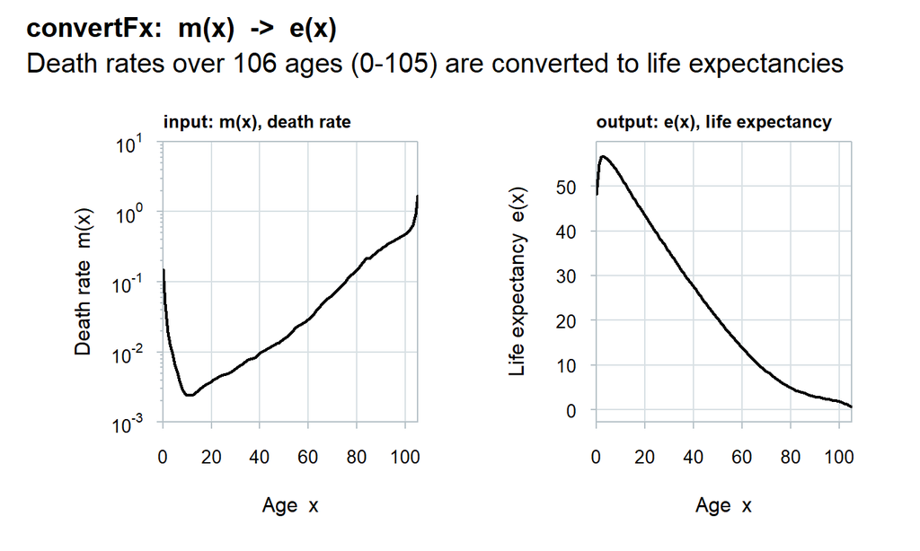

```r
plot(ex_1900)
```

Rates and probabilities go on a log scale in whichever panel they appear, and a matrix input draws one curve per column.

# LawTable: a table from a law

`LawTable()` takes the coefficients of a mortality law and returns the life table the law implies. It is the natural next step after a fit with `MortalityLaw()`, and the only thing to watch is which scale the coefficients live on.

```r
fit <- MortalityLaw(x = 60:100, mx = mx[x >= 60 & x <= 100], law = "gompertz")
coef(fit)
```

```
#>          A          B
#> 0.03065405 0.07179448
```

```r
lt_law <- LawTable(x = 60:100, par = coef(fit), law = "gompertz")
round(head(lt_law$lt[, -1], 3), 4)
```

```
#>    x     mx     qx  ax        lx       dx       Lx      Tx      ex
#> 1 60 0.0329 0.0324 0.5 100000.00 3240.217 98379.89 1378829 13.7883
#> 2 61 0.0354 0.0348 0.5  96759.78 3364.539 95077.51 1280449 13.2333
#> 3 62 0.0380 0.0373 0.5  93395.24 3484.767 91652.86 1185372 12.6920
```

`par` may be a vector or a matrix with one row of coefficients per table, and the law code must be one of the 38 in `availableLaws()`. Laws that fit $q_x$ (like the Heligman-Pollard family) feed probabilities to `LifeTable()`, the rest feed rates. The Gompertz above is one of the `SCALE_X` laws: it rescales the age vector during fitting, so its coefficients refer to ages measured from the start of the fitting range. Here the fit starts at 60 and the table starts at 60, and the law puts $e_{60}$ at 13.79 years against the 13.87 of the data table at the same age. Try the same coefficients at age 20 and the result would be quietly wrong; keep the lower bound of `x` at the lower bound of the fit.

# The ex inverse: a table from life expectancies

The `ex` input answers the question in reverse: given a curve of remaining life expectancy, what life table produced it? The method is the standard textbook inversion (Preston, Heuveline and Guillot 2001, chapter 3, Preston et al. (2001)): it combines the interval identity ${}_nL_x = a_x l_x + (n - a_x) l_{x+n}$ with the $T_x$ recurrence, and both are relations the forward table is built on. The $a_x$ values it uses are the forward table’s own rules: the Andreev-Kingkade $a_0$ and the HMD protocol basis under the default (Andreev and Kingkade (2015); Wilmoth et al. (2025)), the Coale-Demeny variant when you ask for it (Coale et al. (1983)). The recovery rests on one exact identity that holds for any $a_x$:

$$e_x \, l_x - e_{x+n} \, l_{x+n} = {}_nL_x = a_x \, l_x + (n - a_x) \,
l_{x+n}.$$

Divide by $l_x$ and the survivorship ratio of each closed interval falls out:

$$r = \frac{l_{x+n}}{l_x} = \frac{e_x - a_x}{e_{x+n} + n - a_x}$$

which in code is:

```
r = (ex - ax)/(ex_n + n - ax)
```

Then $q_x = 1 - r$ and $m_x = q_x / (a_x q_x + n (1 - q_x))$ follow, and the open interval closes by the usual rule, $a_N = e_N$ and $m_N = 1/e_N$.

There is one catch, and it is a real one: $e_x$ alone does not pin down $a_x$. Pass `ax` as a number and the inversion is exact in one pass, because the ratios come straight from the formula above. Leave it out and it turns into a fixed-point problem: the default rule makes $a_x$ a function of the rate being recovered, so each interval must be solved for the ratio $r$ at which the $a_x$ method in force reproduces it, that is, the root of

$$\frac{e_x - a(r)}{e_{x+n} + n - a(r)} - r = 0$$

by bisection (120 iterations, on $r \in (0, 1)$). The root is unique: the left side is continuous and strictly decreasing in $r$ for every method the package offers. The recovered table is then exactly the one the same $e_x$ curve describes under that method.

```r
lt_back <- LifeTable(x = x, ex = lt_rates$lt$ex)

round(data.frame(
  age    = x[1:3],
  ex_in  = lt_rates$lt$ex[1:3],
  ex_out = lt_back$lt$ex[1:3],
  mx_out = lt_back$lt$mx[1:3]
  ), 5)
```

```
#>   age    ex_in   ex_out  mx_out
#> 1   0 48.25283 48.25283 0.15131
#> 2   1 54.86032 54.86032 0.04793
#> 3   2 56.53001 56.53001 0.01913
```

```r
max(abs(lt_back$lt$ex - lt_rates$lt$ex))
```

```
#> [1] 9.947598e-14
```

The round trip reproduces the input curve to $10^{-13}$. The reverse is not guaranteed: not every curve of $e_x$ is a feasible life table. A curve that rises at young ages is fine (when infant mortality is high, $e_1 > e_0$), but a value below its own $a_x$, or falling faster than the interval width, gives death probabilities outside $[0, 1]$ and the function stops with the offending ages named. A missing value is an error too, never a repaired gap.

# Reading the output

`plot.LifeTable()` draws the four classic panels: survivorship $l(x)$, the hazard $m(x)$ on a log scale, the death distribution $d(x)$, and life expectancy $e(x)$.

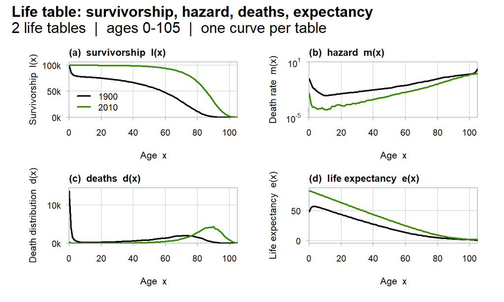

```r
lt_two <- LifeTable(
  x  = x,
  mx = ahmd$mx[as.character(x), c("1900", "2010")]
  )
plot(lt_two)
```

`which` selects a single panel and `split` rearranges the layout:

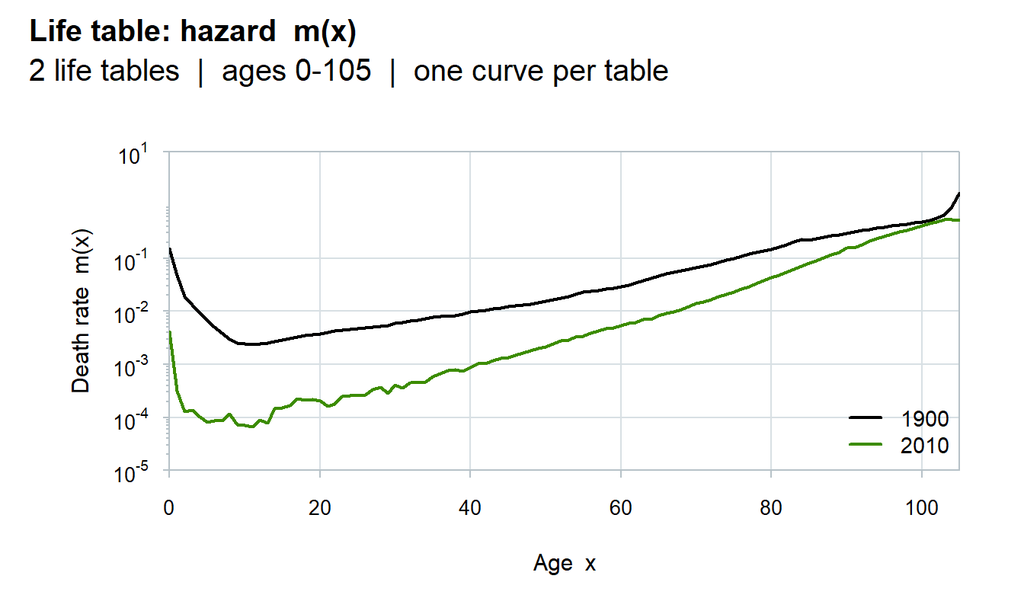

```r
plot(lt_two, which = "hazard")
```

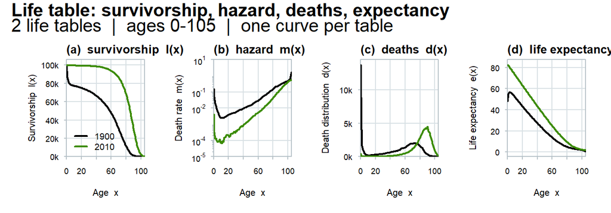

```r
plot(lt_two, split = c(1, 4))
```

The `which` values are `"all"` (the default), `"lx"`, `"hazard"`, `"dx"` and `"ex"`; `split` takes a `c(nrow, ncol)` pair that must hold exactly one slot per panel. The same four panels are what a `LawTable()` object plots, since it returns a `"LifeTable"` like any other.

# References

Andreev, E. M., and W. W. Kingkade. 2015. “Average Age at Death in Infancy and Infant Mortality Level: Reconsidering the Coale-Demeny Formulas at Current Low Levels of Infant Mortality.” *Demographic Research* 33: 727–56.

Coale, A. J., P. Demeny, and B. Vaughan. 1983. *Regional Model Life Tables and Stable Populations*. 2nd ed. Academic Press.

Forfar, D. O., J. J. McCutcheon, and A. D. Wilkie. 1988. “On Graduation by Mathematical Formula.” *Journal of the Institute of Actuaries* 115 (1): 1–149.

Preston, S. H., P. Heuveline, and M. Guillot. 2001. *Demography: Measuring and Modeling Population Processes*. Blackwell Publishers.

Wilmoth, J. R., K. Andreev, D. Jdanov, D. A. Glei, and T. Riffe. 2025. *Methods Protocol for the Human Mortality Database*. Version 6.